# Quintana - Coding Challenge 2

#Question 2 - Make a boxplot using ggplot with DON as the y variable, treatment as the x variable, and color mapped to the wheat cultivar. Show the code you use to load the libraries you need to read in the data and make the plot. Change the y label to “DON (ppm)” and make the x label blank

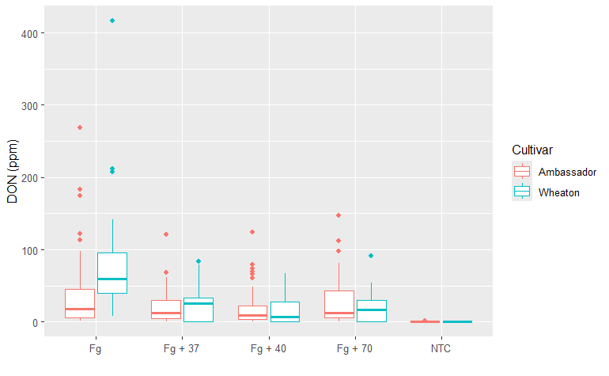

```r
library(ggplot2)
#load data in
mycotoxin <- read.csv("C:/Users/there/Desktop/PLPA 5820/Data Visualization/MycotoxinData.csv")

#boxplot
ggplot(mycotoxin, aes(x = Treatment, y = as.numeric(mycotoxin$DON), color = Cultivar)) +
  geom_boxplot() +
  xlab("") +
  ylab("DON (ppm)")
```

#Question 3 - Now convert this data into a bar chart with standard-error error bars using the stat_summary() command.

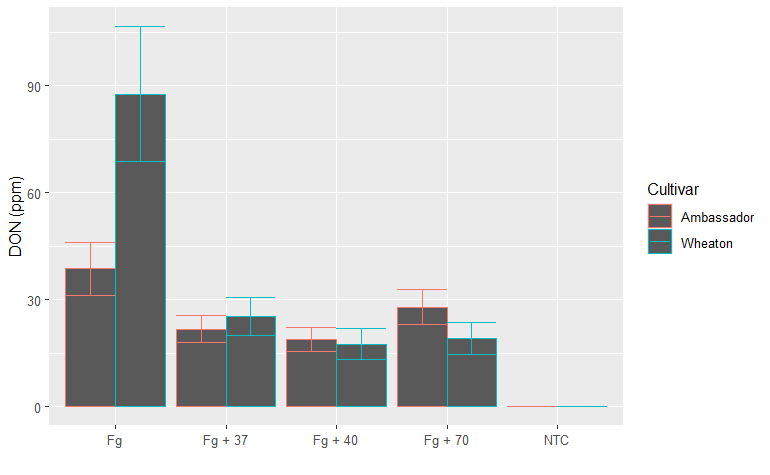

```r
ggplot(mycotoxin, aes(x = Treatment, y = as.numeric(mycotoxin$DON), color = Cultivar)) +
  stat_summary(fun = mean, geom = "bar", position = "dodge") +
  stat_summary(fun.data = mean_se, geom = "errorbar", position = "dodge") +
  xlab("") +
  ylab("DON (ppm)")
```

#Question 4 - Add points to the foreground of the boxplot and bar chart you made in question 3 that show the distribution of points over the boxplots. Set the shape = 21 and the outline color black (hint: use jitter_dodge).

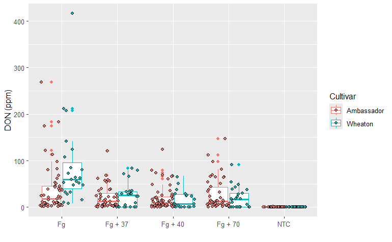

```r
#For boxplot
ggplot(mycotoxin, aes(x = Treatment, y = as.numeric(mycotoxin$DON), color = Cultivar)) +
  geom_boxplot() +
  xlab("") +
  ylab("DON (ppm)") +
  geom_point(aes(fill = Cultivar), position = position_jitterdodge(), shape = 21, color = "black")
```

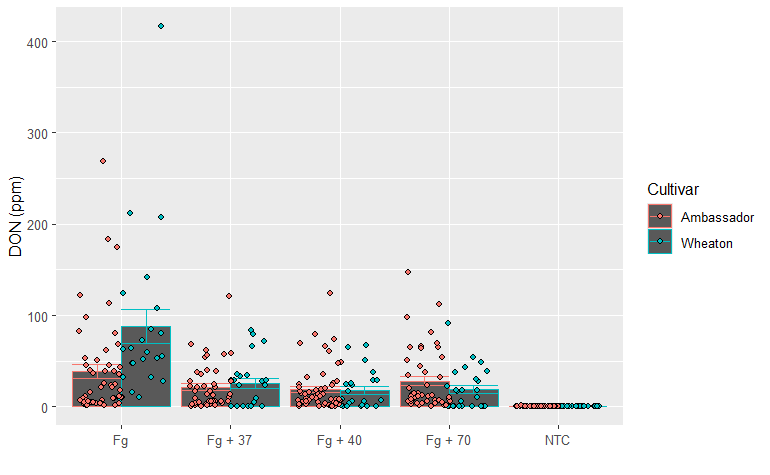

```r
#for barchart
ggplot(mycotoxin, aes(x = Treatment, y = as.numeric(mycotoxin$DON), color = Cultivar)) +
  stat_summary(fun = mean, geom = "bar", position = "dodge") +
  stat_summary(fun.data = mean_se, geom = "errorbar", position = "dodge") +
  xlab("") +
  ylab("DON (ppm)")+
  geom_point(aes(fill = Cultivar), position = position_jitterdodge(), shape = 21, color = "black")
```

#Question 5 - Change the fill color of the points and boxplots to match some colors in the following colorblind pallet

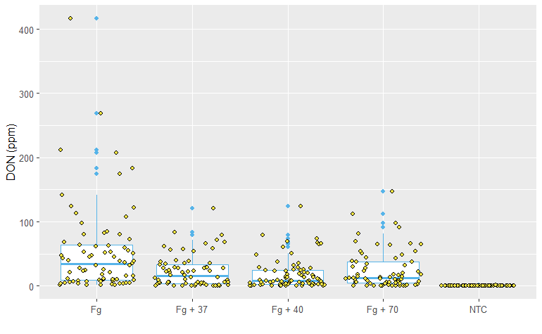

```r
#for boxplot
ggplot(mycotoxin, aes(x = Treatment, y = as.numeric(mycotoxin$DON), color = Cultivar)) +
  geom_boxplot(color = "#56B4E9") +
  xlab("") +
  ylab("DON (ppm)") +
  geom_point(position = position_jitter(), shape = 21, color = "black", fill = "#F0E442")
```

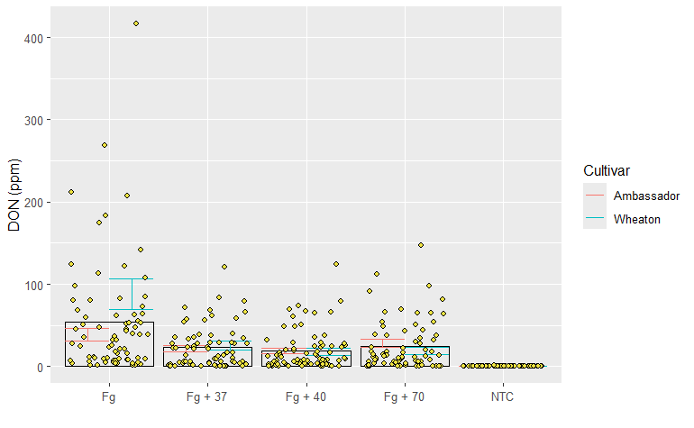

```r
#for barchart
ggplot(mycotoxin, aes(x = Treatment, y = as.numeric(mycotoxin$DON), color = Cultivar)) +
  stat_summary(fun = mean, geom = "bar", fill = NA, color = "black") +
  stat_summary(fun.data = mean_se, geom = "errorbar", position = "dodge") +
  xlab("") +
  ylab("DON (ppm)")+
  geom_point(position = position_jitter(), shape = 21, color = "black", fill = "#F0E442")
```

#Question 6 - Add a facet to the plots based on cultivar

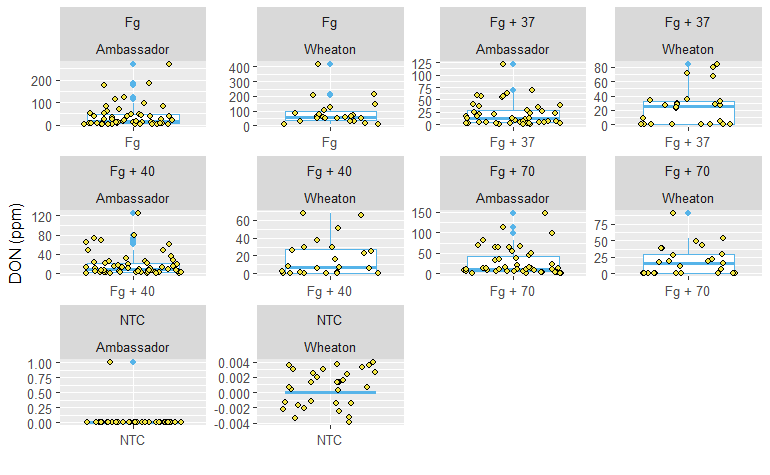

```r
#for boxplot
ggplot(mycotoxin, aes(x = Treatment, y = as.numeric(mycotoxin$DON), color = Cultivar)) +
  geom_boxplot(color = "#56B4E9") +
  xlab("") +
  ylab("DON (ppm)") +
  geom_point(position = position_jitter(), shape = 21, color = "black", fill = "#F0E442") +
    facet_wrap(~Treatment*Cultivar, scales = "free")
```

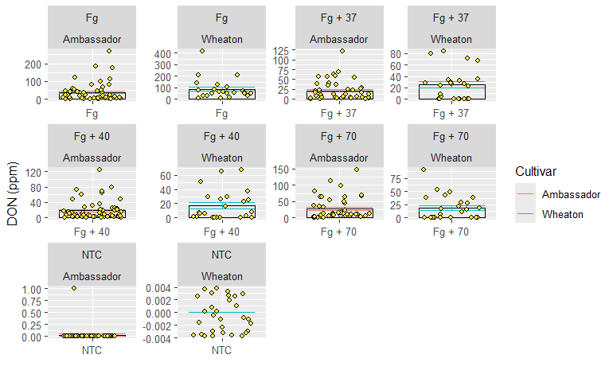

```r
#for barchart
ggplot(mycotoxin, aes(x = Treatment, y = as.numeric(mycotoxin$DON), color = Cultivar)) +
  stat_summary(fun = mean, geom = "bar", fill = NA, color = "black") +
  stat_summary(fun.data = mean_se, geom = "errorbar", position = "dodge") +
  xlab("") +
  ylab("DON (ppm)")+
  geom_point(position = position_jitter(), shape = 21, color = "black", fill = "#F0E442") +
    facet_wrap(~Treatment*Cultivar, scales = "free")
```

#Question 7 - Add transparency to the points so you can still see the boxplot or bar in the background.

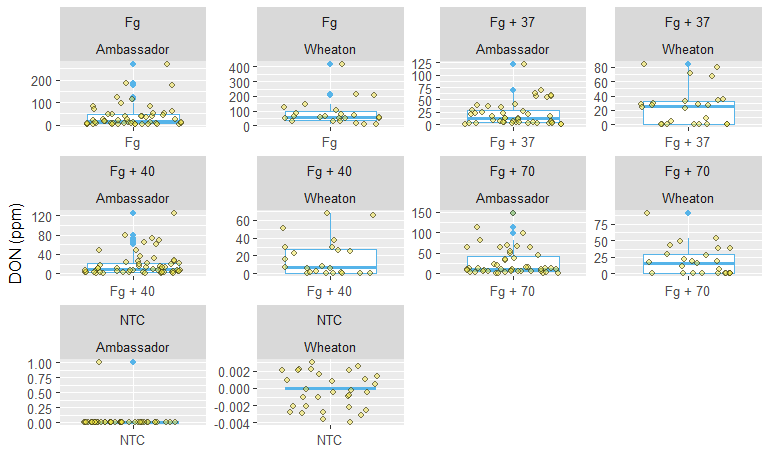

```r
#for boxplot
ggplot(mycotoxin, aes(x = Treatment, y = as.numeric(mycotoxin$DON), color = Cultivar)) +
  geom_boxplot(color = "#56B4E9") +
  xlab("") +
  ylab("DON (ppm)") +
  geom_point(position = position_jitter(), shape = 21, color = "black", fill = "#F0E442", alpha = 0.5) +
    facet_wrap(~Treatment*Cultivar, scales = "free")
```

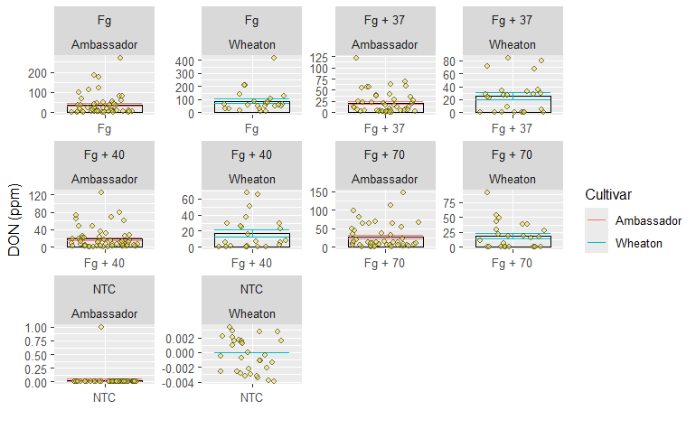

```r
#for barchart
ggplot(mycotoxin, aes(x = Treatment, y = as.numeric(mycotoxin$DON), color = Cultivar)) +
  stat_summary(fun = mean, geom = "bar", fill = NA, color = "black") +
  stat_summary(fun.data = mean_se, geom = "errorbar", position = "dodge") +
  xlab("") +
  ylab("DON (ppm)")+
  geom_point(position = position_jitter(), shape = 21, color = "black", fill = "#F0E442", alpha = 0.5) +
    facet_wrap(~Treatment*Cultivar, scales = "free")
```

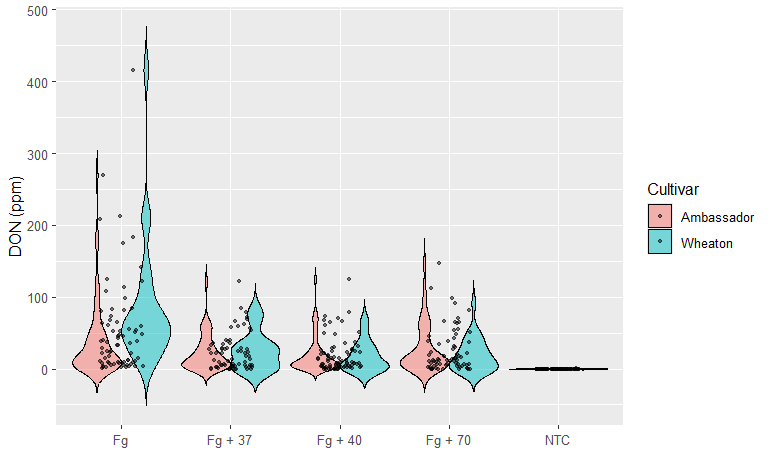

```r
#violin plot
ggplot(mycotoxin, aes(x = Treatment, y = as.numeric(DON), fill = Cultivar)) +
  geom_violin(alpha = 0.5, color = "black", scale = "width", trim = FALSE) +
  geom_jitter(position = position_jitter(width = 0.2), size = 1, alpha = 0.5, color = "black") +
  xlab("") +
  ylab("DON (ppm)")
```